# Exploracion de los datos en Frontur.csv

Sandra de la Fuente

30 de mayo de 2017

# 1 Se establece el directorio de trabajo y las librerías necesarias

library(plyr)  
library(dplyr)  
library(ggplot2)  
library(reshape2)  
library(data.table)

# 2 Exploración de los datos

En este script del TFM, se va a hacer una exploración y transformación de los datos obtenidos del INE para poder plantear una solución, a partir de los mismos, para adecuarlos al problema de modelado que se quiere resolver.

En esta fase se procede, a partir del fichero csv generado en la etapa anterior “data_Cleaning”, a la generación de nuevos registros o valores transformados de atributos existentes, si fuera necesario, en función de los requerimientos para preparar la entrada a las herramientas de modelado.

Cabe recordar que los datos son la representación simbólica (numérica, alfabética,…) de un atributo o variable cuantitativa o cualitativa.

Se procede a dar formato a los datos, estas transformaciones se refieren a modificaciones sintácticas que se hacen sobre ellos, sin alterar su significado pero que pueden ser requeridas por la herramienta de modelado a utilizar.

Puede que haya requisitos en el orden de los atributos o que los registros estén ordenados según el atributo resultado, mediante la evaluación de la información disponible y refinar la pregunta inicial para evitar resultados ambiguos, sesgos o detectar la necesidad de recopilar nuevos datos.

El período de tiempo que se va a utilizar en el TFM, será desde Octubre del 2015 hasta Abril del 2017 (19 meses).

En el fichero Frontur.csv, cada registro representa a un viajero que finaliza su viaje por España en el mes de referencia.

La variable que identifica de manera única cada registro es Id. Sumando el factor de elevación de cada registro (‘Factor’) se obtiene la estimación del número de viajeros, que podrá desglosarse en función del resto de variables de clasificación del fichero: turistas-excursionistas, destino principal, país de residencia, vía de acceso y tipo de alojamiento.

El fichero Paises.csv se relacionan los códigos de cada país, con el nombre del País de residencia habitual del turista.

El fichero CCAA.csv contiene los códigos de las CCAA y su nombre correspondiente como destino principal del viaje.

```r
df_Frontur <- read.table("../data_cleaning_02/Frontur.csv", header = T, sep = "," , fileEncoding = "utf-8")
head(df_Frontur)
```

```
##               Id Tipo_Viajero Via_Entrada Pais Destino_CCAA Alojamiento
## 1 20170102010177            2           2   13           13           8
## 2 20170101010177            2           2   13           13           8
## 3 20170100028497            2           2   13           13           2
## 4 20170101000001            3           2   13            5           0
## 5 20170100020431            2           2   13            5           8
## 6 20170100010177            2           2   13           13           8
##   Motivo Paquete_Turistico Pernoctaciones  Viajeros Mes Anyo
## 1      4                 6              4  90.62923   1   17
## 2      4                 6              4  90.62923   1   17
## 3      1                 6              4 103.61073   1   17
## 4      1                 1              1 238.05977   1   17
## 5      1                 6              4  96.91650   1   17
## 6      4                 6              4  90.62923   1   17
```

```r
df_Paises <- read.table("../data_cleaning_02/Paises.csv", header = T, sep = ";",   fileEncoding="utf-8")
df_Paises
```

```
##    Pais                    Nombre
## 1     1                  Alemania
## 2     2                   Bélgica
## 3     3                    España
## 4     4                   Francia
## 5     5                   Irlanda
## 6     6                    Italia
## 7     7              Países Bajos
## 8     8                  Portugal
## 9     9               Reino Unido
## 10   10          Países Nórdicos
## 11   11                     Rusia
## 12   12                    Suiza
## 13   13          Resto de Europa
## 14   14 Estados Unidos de América
## 15   15        América (sin EEUU)
## 16   16          Resto del mundo
```

```r
df_CCAA <- read.table("../data_cleaning_02/CCAA.csv", header = T, sep = ";",  fileEncoding="utf-8")
df_CCAA
```

```
##    Codigo                    CCAA
## 1       1               Andalucía
## 2       2                 Aragón
## 3       3 Principado de Asturias
## 4       4               Baleares
## 5       5               Canarias
## 6       6              Cantabria
## 7       7       Castilla y León
## 8       8     Castilla La Mancha
## 9       9              Cataluña
## 10     10         Com.Valenciana
## 11     11           Extremadura
## 12     12               Galicia
## 13     13            Com.Madrid
## 14     14      Región de Murcia
## 15     15            C.F.Navarra
## 16     16             País Vasco
## 17     17               La Rioja
## 18     18                   Ceuta
## 19     19                 Melilla
## 20     98                Transito
```

# 3 Formateo de los datos

Se formatea los datos a los tipos adecuados: 1. Tipos numéricos (Viajeros) 2. Tipos Categóricos (Tipo_Viajero, Via_Entrada, Pais, Destino_CCAA, Alojamiento, Motivo, Paquete_Turistico , Pernoctaciones y Mes)

```r
df_Frontur$Viajeros<-as.numeric(df_Frontur$Viajeros)

df_Frontur$Tipo_Viajero<-as.factor(df_Frontur$Tipo_Viajero)
df_Frontur$Via_Entrada<-as.factor(df_Frontur$Via_Entrada)
df_Frontur$Pais<-as.factor(df_Frontur$Pais)
df_Frontur$Destino_CCAA<-as.factor(df_Frontur$Destino_CCAA)
df_Frontur$Alojamiento<-as.factor(df_Frontur$Alojamiento)
df_Frontur$Motivo<-as.factor(df_Frontur$Motivo)
df_Frontur$Pernoctaciones<-as.factor(df_Frontur$Pernoctaciones)
df_Frontur$Mes<-as.factor(df_Frontur$Mes)
df_Frontur$Anyo<-as.factor(df_Frontur$Anyo)
df_Frontur$Paquete_Turistico<-as.factor(df_Frontur$Paquete_Turistico)


head(df_Frontur)
```

```
##               Id Tipo_Viajero Via_Entrada Pais Destino_CCAA Alojamiento
## 1 20170102010177            2           2   13           13           8
## 2 20170101010177            2           2   13           13           8
## 3 20170100028497            2           2   13           13           2
## 4 20170101000001            3           2   13            5           0
## 5 20170100020431            2           2   13            5           8
## 6 20170100010177            2           2   13           13           8
##   Motivo Paquete_Turistico Pernoctaciones  Viajeros Mes Anyo
## 1      4                 6              4  90.62923   1   17
## 2      4                 6              4  90.62923   1   17
## 3      1                 6              4 103.61073   1   17
## 4      1                 1              1 238.05977   1   17
## 5      1                 6              4  96.91650   1   17
## 6      4                 6              4  90.62923   1   17
```

```r
df_Paises$Pais<-as.factor(df_Paises$Pais)

df_CCAA$Codigo<-as.factor(df_CCAA$Codigo)
colnames(df_CCAA)[colnames(df_CCAA)=="Codigo"] <- "Destino_CCAA"
```

# 4 Revisión de los datos del fichero csv

```r
head(df_Frontur)
```

```
##               Id Tipo_Viajero Via_Entrada Pais Destino_CCAA Alojamiento
## 1 20170102010177            2           2   13           13           8
## 2 20170101010177            2           2   13           13           8
## 3 20170100028497            2           2   13           13           2
## 4 20170101000001            3           2   13            5           0
## 5 20170100020431            2           2   13            5           8
## 6 20170100010177            2           2   13           13           8
##   Motivo Paquete_Turistico Pernoctaciones  Viajeros Mes Anyo
## 1      4                 6              4  90.62923   1   17
## 2      4                 6              4  90.62923   1   17
## 3      1                 6              4 103.61073   1   17
## 4      1                 1              1 238.05977   1   17
## 5      1                 6              4  96.91650   1   17
## 6      4                 6              4  90.62923   1   17
```

```r
tail(df_Frontur)
```

```
##                    Id Tipo_Viajero Via_Entrada Pais Destino_CCAA
## 994344 20151201004049            2           2   16           16
## 994345 20151200022260            2           2   16            1
## 994346 20151200021221            2           2   16            4
## 994347 20151200006418            2           4   16            9
## 994348 20151200018582            2           2   16            1
## 994349 20151200004049            2           2   16           16
##        Alojamiento Motivo Paquete_Turistico Pernoctaciones Viajeros Mes
## 994344           8      4                 6              5 53.49228  12
## 994345           2      2                 6              6 80.30343  12
## 994346           7      1                 6              4 20.35763  12
## 994347           6      1                 1              5 35.94221  12
## 994348           8      1                 6              6 87.05811  12
## 994349           8      4                 6              5 53.49228  12
##        Anyo
## 994344   15
## 994345   15
## 994346   15
## 994347   15
## 994348   15
## 994349   15
```

```r
nrow(df_Frontur)
```

```
## [1] 994349
```

```r
ncol(df_Frontur)
```

```
## [1] 12
```

```r
str(df_Frontur)
```

```
## 'data.frame':    994349 obs. of  12 variables:
##  $ Id               : Factor w/ 924141 levels "0114EVA0000376",..: 772936 765282 760574 761732 755680 749891 743179 747848 750201 751443 ...
##  $ Tipo_Viajero     : Factor w/ 2 levels "2","3": 1 1 1 2 1 1 2 1 1 1 ...
##  $ Via_Entrada      : Factor w/ 4 levels "1","2","3","4": 2 2 2 2 2 2 2 2 2 2 ...
##  $ Pais             : Factor w/ 15 levels "1","2","4","5",..: 12 12 12 12 12 12 12 12 12 12 ...
##  $ Destino_CCAA     : Factor w/ 19 levels "1","2","3","4",..: 13 13 13 5 5 13 5 4 9 9 ...
##  $ Alojamiento      : Factor w/ 10 levels "0","1","2","3",..: 9 9 3 1 9 9 1 2 9 3 ...
##  $ Motivo           : Factor w/ 5 levels "1","2","3","4",..: 4 4 1 1 1 4 1 1 1 1 ...
##  $ Paquete_Turistico: Factor w/ 3 levels "0","1","6": 3 3 3 2 3 3 2 3 3 3 ...
##  $ Pernoctaciones   : Factor w/ 6 levels "1","2","3","4",..: 4 4 4 1 4 4 1 3 5 3 ...
##  $ Viajeros         : num  90.6 90.6 103.6 238.1 96.9 ...
##  $ Mes              : Factor w/ 12 levels "1","2","3","4",..: 1 1 1 1 1 1 1 1 1 1 ...
##  $ Anyo             : Factor w/ 3 levels "15","16","17": 3 3 3 3 3 3 3 3 3 3 ...
```

Se procede a comparar los datos obtenidos del dataset, con la documentacion del INE (fichero /data_01/Frontur/Diseño_Frontur_OpenData.xlsx en ), para detectar posibles datos nulos, outliers o datos erróneos.

Se detecta que los levels de las columnas (Pais, Destino y Motivo), no coinciden con los de la documentación, por lo que se procede a la revisión de los mismos.

```r
head(df_Frontur$Pais)
```

```
## [1] 13 13 13 13 13 13
## Levels: 1 2 4 5 6 7 8 9 10 11 12 13 14 15 16
```

Se detecta que no tiene el valor 3 que corresponde con España, por lo tanto es correcto que solo haya 15 valores puesto que los datos son de turistas extranjeros.

```r
head(df_Frontur$Destino_CCAA)
```

```
## [1] 13 13 13 5  5  13
## Levels: 1 2 3 4 5 6 7 8 9 10 11 12 13 14 15 16 17 18 98
```

No aparece Melilla (código = 19) como Destino principal del viaje, en cambio, como dato curioso Ceuta sí que aparece.

```r
head(df_Frontur$Motivo)
```

```
## [1] 4 4 1 1 1 4
## Levels: 1 2 3 4 5
```

En el caso de los motivos del viaje, se detecta que el valor 0 que significa “no procede” no aparece en ningún registro del dataset.

# 5 Valores perdidos (missing values)

El tratamiento de los datos es fundamental para la correcta interpretación de un análisis, los valores perdidos son aquellos que simplemente se ha perdido algún dato y no sabemos qué valor toma, se representa por el código: NA (Not available).

Hay muchas funciones para identificar estos valores, la más usada es is.na(), en este dataset no existen valores NaN ni NA.

```r
sapply(df_Frontur,function(x) sum(is.na(x)))
```

```
##                Id      Tipo_Viajero       Via_Entrada              Pais
##                 0                 0                 0                 0
##      Destino_CCAA       Alojamiento            Motivo Paquete_Turistico
##                 0                 0                 0                 0
##    Pernoctaciones          Viajeros               Mes              Anyo
##                 0                 0                 0                 0
```

# 6 Análisis descriptivo de los datos

```r
summary(df_Frontur)
```

```
##               Id         Tipo_Viajero Via_Entrada      Pais
##  20150200049950:    21   2:804850     1: 92989    9      :188304
##  20151000027386:    20   3:189499     2:779904    4      :148544
##  20151000003194:    19                3:108114    1      :118363
##  20151000004521:    19                4: 13342    6      : 83842
##  20151000004528:    19                            10     : 67714
##  20151000007831:    19                            16     : 64338
##  (Other)       :994232                            (Other):323244
##   Destino_CCAA     Alojamiento     Motivo     Paquete_Turistico
##  9      :210745   1      :507687   1:766587   0: 40517
##  5      :150731   0      :189499   2: 74082   1:291802
##  4      :150105   8      :116611   3: 18193   6:662030
##  10     :106199   2      : 84651   4: 56746
##  1      :103245   7      : 54929   5: 78741
##  98     : 95526   9      : 13396
##  (Other):177798   (Other): 27576
##  Pernoctaciones    Viajeros              Mes         Anyo
##  1:189499       Min.   :     0.02   4      :121714   15:149036
##  2: 30320       1st Qu.:    49.48   10     :110001   16:645446
##  3:145207       Median :    95.62   3      : 96405   17:199867
##  4:390353       Mean   :   170.35   11     : 95133
##  5:177837       3rd Qu.:   170.99   2      : 93546
##  6: 61133       Max.   :102509.74   12     : 85468
##                                     (Other):392082
```

Total de turistas que vienen a España durante el periodo Octubre 2015 a Abril 2017, son 169.385.169 y de media 170.3478

```r
summarize(df_Frontur, total = sum(df_Frontur$Viajeros, na.rm = T), media = mean(df_Frontur$Viajeros, na.rm = T))
```

```
##       total    media
## 1 169385169 170.3478
```

Llegada de turistas internacionales por país de residencia, porcentaje respecto al total.

```r
res <- ddply(df_Frontur, .(Pais), summarize, Total = sum(Viajeros))

res2 <- ddply(res, .(Pais, Total), transform, pct= 100 * Total / sum(df_Frontur$Viajeros))
res2
```

```
##    Pais    Total        pct
## 1     1 17615096 10.3994322
## 2     2  3860307  2.2790115
## 3     4 48070653 28.3794932
## 4     5  2615077  1.5438644
## 5     6  7882362  4.6535136
## 6     7  5163746  3.0485233
## 7     8 15859465  9.3629597
## 8     9 27456890 16.2097369
## 9    10  8359960  4.9354735
## 10   11  1491820  0.8807262
## 11   12  3347748  1.9764117
## 12   13 10570837  6.2407102
## 13   14  3915676  2.3116995
## 14   15  5836026  3.4454173
## 15   16  7339505  4.3330270
```

```r
df_merge  <- inner_join(res2,df_Paises)
df_merge
```

```
##    Pais    Total        pct                    Nombre
## 1     1 17615096 10.3994322                  Alemania
## 2     2  3860307  2.2790115                   Bélgica
## 3     4 48070653 28.3794932                   Francia
## 4     5  2615077  1.5438644                   Irlanda
## 5     6  7882362  4.6535136                    Italia
## 6     7  5163746  3.0485233              Países Bajos
## 7     8 15859465  9.3629597                  Portugal
## 8     9 27456890 16.2097369               Reino Unido
## 9    10  8359960  4.9354735          Países Nórdicos
## 10   11  1491820  0.8807262                     Rusia
## 11   12  3347748  1.9764117                    Suiza
## 12   13 10570837  6.2407102          Resto de Europa
## 13   14  3915676  2.3116995 Estados Unidos de América
## 14   15  5836026  3.4454173        América (sin EEUU)
## 15   16  7339505  4.3330270          Resto del mundo
```

Se representa de forma gráfica con un diagrama de barras, la llegada de turistas internacionales por país de residencia en porcentajes al total.

Francia es el principal país de residencia con 48.070.653 turistas durante el periodo de estudio, lo que representa el 28 % del total.

Reino Unido y Alemania son los siguientes países de residencia con más turistas que visitan España.

```r
df_merge<-df_merge[order(df_merge$Total,decreasing=T),]

df_merge
```

```
##    Pais    Total        pct                    Nombre
## 3     4 48070653 28.3794932                   Francia
## 8     9 27456890 16.2097369               Reino Unido
## 1     1 17615096 10.3994322                  Alemania
## 7     8 15859465  9.3629597                  Portugal
## 12   13 10570837  6.2407102          Resto de Europa
## 9    10  8359960  4.9354735          Países Nórdicos
## 5     6  7882362  4.6535136                    Italia
## 15   16  7339505  4.3330270          Resto del mundo
## 14   15  5836026  3.4454173        América (sin EEUU)
## 6     7  5163746  3.0485233              Países Bajos
## 13   14  3915676  2.3116995 Estados Unidos de América
## 2     2  3860307  2.2790115                   Bélgica
## 11   12  3347748  1.9764117                    Suiza
## 4     5  2615077  1.5438644                   Irlanda
## 10   11  1491820  0.8807262                     Rusia
```

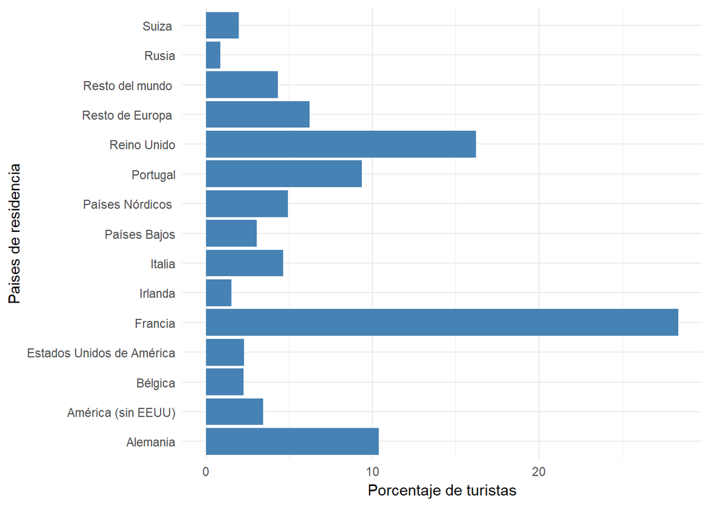

```r
ggplot(data=df_merge, aes(y=pct, x=Nombre)) +
  geom_bar(stat="identity", fill="steelblue",  width=0.9) +
   labs(x = "Paises de residencia", y = "Porcentaje de turistas")+
  coord_flip() +
  theme_minimal()
```

Se representa de forma gráfica con un diagrama de barras,las Comunidades Autónomas de destino principal, porcentaje respecto al total.

Cataluña es el principal destino principal de los turistas con 40294779.77 turistas durante el periodo de estudio, lo que representa el 24 % del total.

Canarias (13%) y Andalucía (11%) son las siguientes Comunidades Autónomas con más turistas que visitan España.

```r
res3 <- ddply(df_Frontur, .(Destino_CCAA), summarize, Total = sum(Viajeros))

res4 <- ddply(res3, .(Destino_CCAA, Total), transform, pct= 100 * Total / sum(df_Frontur$Viajeros))
res4
```

```
##    Destino_CCAA       Total         pct
## 1             1 18537136.49 10.94377777
## 2             2  1258186.31  0.74279603
## 3             3   402999.64  0.23791908
## 4             4 16770055.00  9.90054506
## 5             5 22309043.89 13.17060047
## 6             6   548304.05  0.32370251
## 7             7  3784724.75  2.23438968
## 8             8   378290.50  0.22333154
## 9             9 40294779.77 23.78884760
## 10           10 11509430.97  6.79482804
## 11           11  2614553.48  1.54355514
## 12           12  6256061.79  3.69339407
## 13           13  9451653.54  5.57997703
## 14           14  1476320.85  0.87157622
## 15           15  3897347.71  2.30087895
## 16           16 12297840.48  7.26028172
## 17           17   203981.28  0.12042452
## 18           18    19890.54  0.01174279
## 19           98 17374568.20 10.25743179
```

```r
df_mergeCCAA  <- inner_join(res4,df_CCAA)
df_mergeCCAA <- df_mergeCCAA[order(df_mergeCCAA$Total,decreasing=T),]

df_mergeCCAA
```

```
##    Destino_CCAA       Total         pct                    CCAA
## 9             9 40294779.77 23.78884760              Cataluña
## 5             5 22309043.89 13.17060047               Canarias
## 1             1 18537136.49 10.94377777               Andalucía
## 19           98 17374568.20 10.25743179                Transito
## 4             4 16770055.00  9.90054506               Baleares
## 16           16 12297840.48  7.26028172             País Vasco
## 10           10 11509430.97  6.79482804         Com.Valenciana
## 13           13  9451653.54  5.57997703            Com.Madrid
## 12           12  6256061.79  3.69339407               Galicia
## 15           15  3897347.71  2.30087895            C.F.Navarra
## 7             7  3784724.75  2.23438968       Castilla y León
## 11           11  2614553.48  1.54355514           Extremadura
## 14           14  1476320.85  0.87157622      Región de Murcia
## 2             2  1258186.31  0.74279603                 Aragón
## 6             6   548304.05  0.32370251              Cantabria
## 3             3   402999.64  0.23791908 Principado de Asturias
## 8             8   378290.50  0.22333154     Castilla La Mancha
## 17           17   203981.28  0.12042452               La Rioja
## 18           18    19890.54  0.01174279                   Ceuta
```

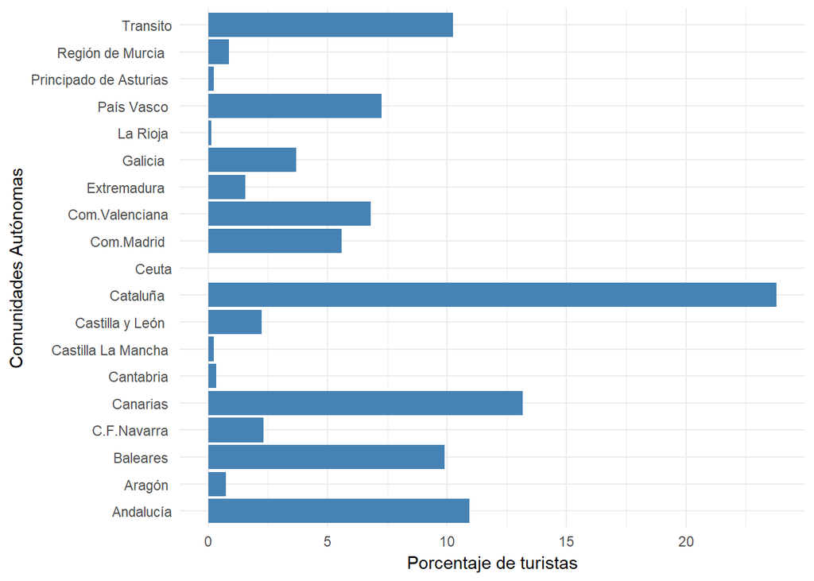

```r
ggplot(data=df_mergeCCAA, aes(y=pct, x=CCAA)) +
  geom_bar(stat="identity", fill="steelblue",  width=0.9) +
   labs(x = "Comunidades Autónomas", y = "Porcentaje de turistas")+
  coord_flip() +
  theme_minimal()
```

El mes con mayor número de turistas que visitaron España fue Agosto del 2016.

```r
Ft_dt <- data.table(df_Frontur)

Ft_dt2 <- Ft_dt[, list(Viajeros = sum(Viajeros)), by = c("Anyo","Mes")]

Ft_dt2 <- arrange(Ft_dt2,desc(Viajeros))

head(Ft_dt2,20)
```

```
##    Anyo Mes Viajeros
## 1    16   8 15812959
## 2    16   7 14080512
## 3    16   9 11274654
## 4    16   6 10915614
## 5    17   4 10610972
## 6    16   5 10448571
## 7    16  10 10231248
## 8    15  10  9940966
## 9    16   4  9265597
## 10   16   3  7684502
## 11   17   3  7565884
## 12   16  12  6863190
## 13   16  11  6639102
## 14   17   2  6605752
## 15   15  11  6429628
## 16   15  12  6417639
## 17   16   2  6254862
## 18   17   1  6210200
## 19   16   1  6133318
```

Se obtiene el número de turistas internacionales por meses y Destino_CCAA, variación temporal Octubre 2015 a Abril 2017.

De los datos se obtiene que el mes de Julio de 2016 hubo la mayor cantidad de viajeros que visitaron Cataluña como principal destino turístico nacional.

```r
Ft_dt3 <- Ft_dt[, list(Viajeros = sum(Viajeros)), by = c("Anyo","Mes", "Destino_CCAA")]

Ft_dt3 <- arrange(Ft_dt3,desc(Viajeros))

head(Ft_dt3,20)
```

```
##    Anyo Mes Destino_CCAA Viajeros
## 1    16   7            9  3561933
## 2    16   8            9  3362215
## 3    16   6            9  2710796
## 4    16   9            9  2620370
## 5    16   5            9  2535176
## 6    16   7            4  2491820
## 7    16   8           98  2463763
## 8    15  10            9  2412173
## 9    16   4            9  2382696
## 10   17   4            9  2365661
## 11   16   8            4  2346608
## 12   16  10            9  2336412
## 13   16   6            4  2000063
## 14   16   9            4  1897634
## 15   16   3            9  1830048
## 16   15  12            9  1730792
## 17   16   5            4  1722439
## 18   15  11            9  1699104
## 19   16   8            1  1654304
## 20   17   3            9  1626032
```

Se utiliza un ggplot para representar la relación entre Viajeros, Destino_CCAA y año.

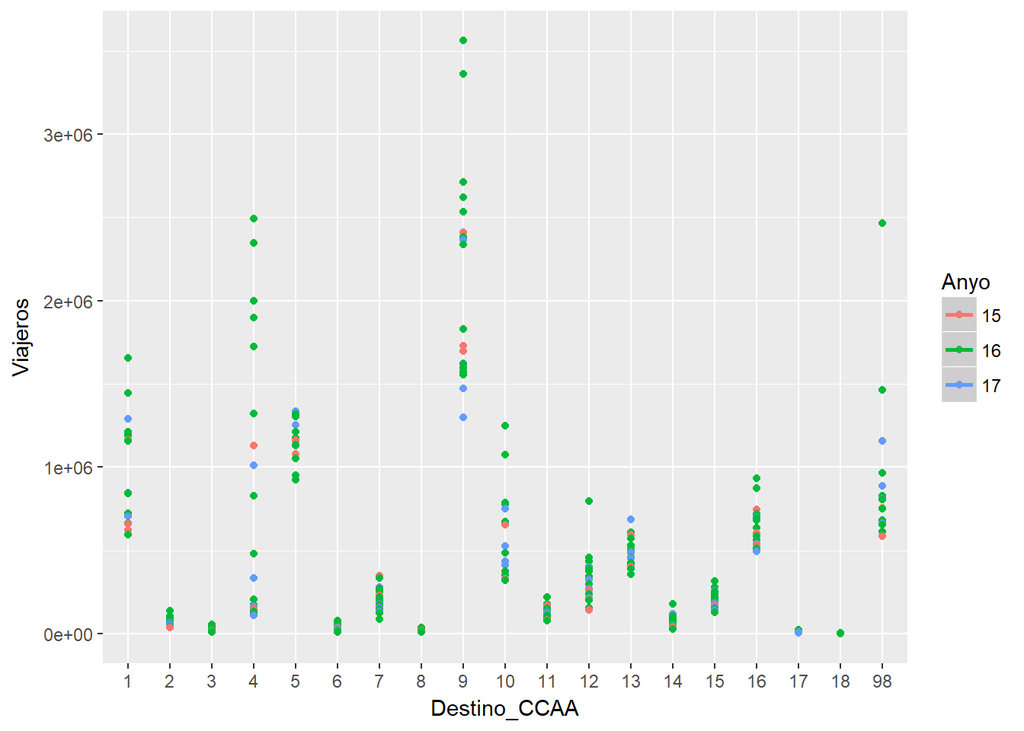

```r
  ggplot(Ft_dt3, aes(x = Destino_CCAA, y = Viajeros, col=Anyo)) +
    geom_point() + geom_smooth()
```

```r
tail(Ft_dt3,20)
```

```
##     Anyo Mes Destino_CCAA   Viajeros
## 342   16   7           18 4217.51900
## 343   17   1           17 4016.58095
## 344   16   8           18 3874.54844
## 345   16   5           18 2876.36610
## 346   16  10           18 1408.65460
## 347   16   4           18 1299.06115
## 348   17   2           18 1050.35848
## 349   15  12           18  904.58083
## 350   16   6           18  831.89389
## 351   17   4           18  795.17002
## 352   16  11           18  547.28671
## 353   16   9           18  459.86246
## 354   17   1           18  350.30854
## 355   17   3           18  289.13687
## 356   16   1           18  286.55175
## 357   16   3           18  232.05636
## 358   16   2           18  187.34083
## 359   15  10           18  120.50877
## 360   15  11           18   92.26590
## 361   16  12           18   67.07425
```

Los franceses son los extranjeros que más visitaron España durante el mes de Agosto del 2016.

```r
Ft_dt4 <- Ft_dt[, list(Viajeros = sum(Viajeros)), by = c("Anyo","Mes", "Pais")]

Ft_dt4 <- arrange(Ft_dt4,desc(Viajeros))

head(Ft_dt4,20)
```

```
##    Anyo Mes Pais Viajeros
## 1    16   8    4  5567798
## 2    16   7    4  3889578
## 3    17   4    4  2976705
## 4    15  10    4  2961420
## 5    16   4    4  2869091
## 6    16   5    4  2806545
## 7    16   9    4  2695369
## 8    16   6    4  2556529
## 9    16  10    4  2528190
## 10   16   8    9  2449531
## 11   16   7    9  2357276
## 12   16   6    9  2242832
## 13   16   9    9  2175566
## 14   16   3    4  2149118
## 15   16  12    4  2118707
## 16   15  12    4  2083752
## 17   17   3    4  1948524
## 18   16   5    9  1946073
## 19   15  11    4  1941595
## 20   16   2    4  1900252
```

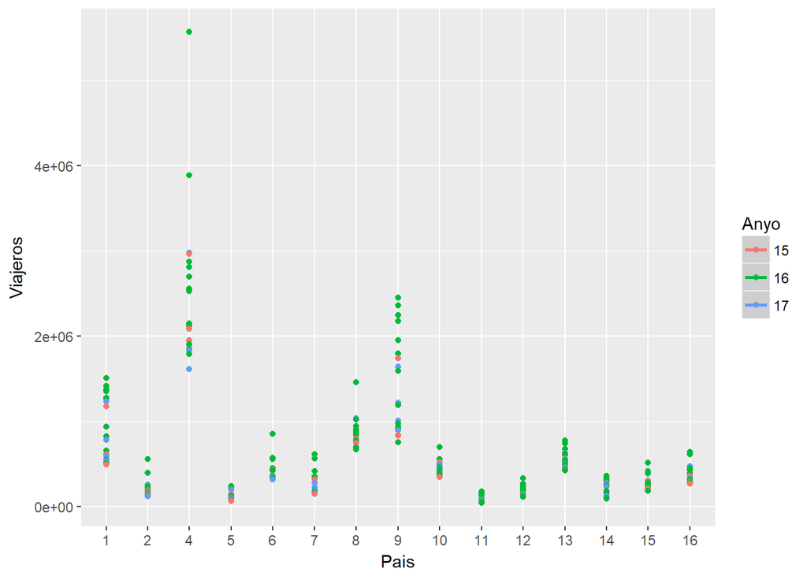

```r
  ggplot(Ft_dt4, aes(x = Pais, y = Viajeros, col=Anyo)) +
    geom_point() + geom_smooth()
```

```r
tail(Ft_dt4,20)
```

```
##     Anyo Mes Pais Viajeros
## 266   16  10   11 82374.55
## 267   16  12    5 81494.09
## 268   17   2    5 79458.93
## 269   16   1    5 73368.16
## 270   17   4   11 73135.04
## 271   17   1   11 73128.09
## 272   16   2    5 72620.49
## 273   15  11    5 70769.71
## 274   16   1   11 69719.23
## 275   15  10   11 65779.71
## 276   15  12    5 61515.61
## 277   16   4   11 57526.09
## 278   17   3   11 56100.93
## 279   15  11   11 52957.15
## 280   17   2   11 52657.50
## 281   16   3   11 49570.44
## 282   16  12   11 48085.06
## 283   16  11   11 44341.79
## 284   15  12   11 42608.37
## 285   16   2   11 40270.79
```

Se generan varios ficheros para poder utilizarlos en las siguientes etapas (prediction & visualization) con los datos del dataset.

```r
write.csv(df_Frontur,file="fronturGLM.csv",row.names = FALSE )

write.csv(Ft_dt4,file="viajeros_fec_pais.csv",row.names = FALSE )
write.csv(Ft_dt3,file="viajeros_fec_ccaa.csv",row.names = FALSE )

write.csv(df_Frontur,file="dsFrontur_Final.csv",row.names = FALSE )
```